# Risk Factor Analysis

## Outcome Variable

**Outcome Variable:** ever_swasted

## Predictor Variables

**Intervention Variable:** mhtcm

**Adjustment Set:**

- arm
- W_mage
- meducyrs
- feducyrs
- hhwealth_quart
- delta_W_mage
- delta_meducyrs
- delta_feducyrs
- delta_hhwealth_quart

## Stratifying Variables

The analysis was stratified on these variable(s):

- agecat
- studyid
- country

## Data Summary

| agecat | studyid | country | mhtcm | ever_swasted | n_cell | n |
| --- | --- | --- | --- | --- | --- | --- |
| 0-24 months | COHORTS | GUATEMALA | >=155 cm | 0 | 149 | 1275 |
| 0-24 months | COHORTS | GUATEMALA | >=155 cm | 1 | 16 | 1275 |
| 0-24 months | COHORTS | GUATEMALA | <151 cm | 0 | 772 | 1275 |
| 0-24 months | COHORTS | GUATEMALA | <151 cm | 1 | 63 | 1275 |
| 0-24 months | COHORTS | GUATEMALA | [151-155) cm | 0 | 257 | 1275 |
| 0-24 months | COHORTS | GUATEMALA | [151-155) cm | 1 | 18 | 1275 |
| 0-24 months | COHORTS | INDIA | >=155 cm | 0 | 514 | 1905 |
| 0-24 months | COHORTS | INDIA | >=155 cm | 1 | 57 | 1905 |
| 0-24 months | COHORTS | INDIA | <151 cm | 0 | 736 | 1905 |
| 0-24 months | COHORTS | INDIA | <151 cm | 1 | 87 | 1905 |
| 0-24 months | COHORTS | INDIA | [151-155) cm | 0 | 458 | 1905 |
| 0-24 months | COHORTS | INDIA | [151-155) cm | 1 | 53 | 1905 |
| 0-24 months | COHORTS | PHILIPPINES | >=155 cm | 0 | 549 | 3045 |
| 0-24 months | COHORTS | PHILIPPINES | >=155 cm | 1 | 80 | 3045 |
| 0-24 months | COHORTS | PHILIPPINES | <151 cm | 0 | 1346 | 3045 |
| 0-24 months | COHORTS | PHILIPPINES | <151 cm | 1 | 194 | 3045 |
| 0-24 months | COHORTS | PHILIPPINES | [151-155) cm | 0 | 768 | 3045 |
| 0-24 months | COHORTS | PHILIPPINES | [151-155) cm | 1 | 108 | 3045 |
| 0-24 months | Guatemala BSC | GUATEMALA | >=155 cm | 0 | 36 | 235 |
| 0-24 months | Guatemala BSC | GUATEMALA | >=155 cm | 1 | 0 | 235 |
| 0-24 months | Guatemala BSC | GUATEMALA | <151 cm | 0 | 141 | 235 |
| 0-24 months | Guatemala BSC | GUATEMALA | <151 cm | 1 | 2 | 235 |
| 0-24 months | Guatemala BSC | GUATEMALA | [151-155) cm | 0 | 56 | 235 |
| 0-24 months | Guatemala BSC | GUATEMALA | [151-155) cm | 1 | 0 | 235 |
| 0-24 months | iLiNS-Zinc | BURKINA FASO | >=155 cm | 0 | 2770 | 3217 |
| 0-24 months | iLiNS-Zinc | BURKINA FASO | >=155 cm | 1 | 130 | 3217 |
| 0-24 months | iLiNS-Zinc | BURKINA FASO | <151 cm | 0 | 82 | 3217 |
| 0-24 months | iLiNS-Zinc | BURKINA FASO | <151 cm | 1 | 9 | 3217 |
| 0-24 months | iLiNS-Zinc | BURKINA FASO | [151-155) cm | 0 | 211 | 3217 |
| 0-24 months | iLiNS-Zinc | BURKINA FASO | [151-155) cm | 1 | 15 | 3217 |

[output cut: 108 more lines]

The following strata were considered:

- agecat: 0-24 months, studyid: COHORTS, country: GUATEMALA
- agecat: 0-24 months, studyid: COHORTS, country: INDIA
- agecat: 0-24 months, studyid: COHORTS, country: PHILIPPINES
- agecat: 0-24 months, studyid: Guatemala BSC, country: GUATEMALA
- agecat: 0-24 months, studyid: iLiNS-Zinc, country: BURKINA FASO
- agecat: 0-24 months, studyid: JiVitA-3, country: BANGLADESH
- agecat: 0-24 months, studyid: Keneba, country: GAMBIA
- agecat: 0-24 months, studyid: LCNI-5, country: MALAWI
- agecat: 0-24 months, studyid: MAL-ED, country: BANGLADESH
- agecat: 0-24 months, studyid: MAL-ED, country: BRAZIL
- agecat: 0-24 months, studyid: MAL-ED, country: INDIA
- agecat: 0-24 months, studyid: MAL-ED, country: NEPAL
- agecat: 0-24 months, studyid: MAL-ED, country: PERU
- agecat: 0-24 months, studyid: MAL-ED, country: SOUTH AFRICA
- agecat: 0-24 months, studyid: MAL-ED, country: TANZANIA, UNITED REPUBLIC OF
- agecat: 0-24 months, studyid: NIH-Birth, country: BANGLADESH
- agecat: 0-24 months, studyid: NIH-Crypto, country: BANGLADESH
- agecat: 0-24 months, studyid: PROBIT, country: BELARUS
- agecat: 0-24 months, studyid: PROVIDE, country: BANGLADESH
- agecat: 0-24 months, studyid: SAS-CompFeed, country: INDIA
- agecat: 0-24 months, studyid: SAS-FoodSuppl, country: INDIA
- agecat: 0-24 months, studyid: TanzaniaChild2, country: TANZANIA, UNITED REPUBLIC OF
- agecat: 0-24 months, studyid: ZVITAMBO, country: ZIMBABWE

### Dropped Strata

Some strata were dropped due to rare outcomes:

- agecat: 0-24 months, studyid: Guatemala BSC, country: GUATEMALA
- agecat: 0-24 months, studyid: LCNI-5, country: MALAWI
- agecat: 0-24 months, studyid: MAL-ED, country: BANGLADESH
- agecat: 0-24 months, studyid: MAL-ED, country: BRAZIL
- agecat: 0-24 months, studyid: MAL-ED, country: INDIA
- agecat: 0-24 months, studyid: MAL-ED, country: NEPAL
- agecat: 0-24 months, studyid: MAL-ED, country: PERU
- agecat: 0-24 months, studyid: MAL-ED, country: SOUTH AFRICA
- agecat: 0-24 months, studyid: MAL-ED, country: TANZANIA, UNITED REPUBLIC OF

## Methods Detail

We're interested in the causal parameters $E[Y_a]$ for all values of $a \in \mathcal{A}$. These parameters represent the mean outcome if, possibly contrary to fact, we intervened to set all units to have $A=a$. Under the randomization and positivity assumptions, these are identified by the statistical parameters $\psi_a=E_W[E_{Y|A,W}(Y|A=a,W)]$. In addition, we're interested in the mean of $Y$, $E[Y]$ under no intervention (the observed mean). We will estimate these parameters by using SuperLearner to fit the relevant likelihood factors -- $E_{Y|A,W}(Y|A=a,W)$ and $p(A=a|W)$, and then updating our likelihood fit using a joint TMLE.

For unadjusted analyses ($W=\{\}$), initial likelihoods were estimated using Lrnr_glm to estimate the simple $E(Y|A)$ and Lrnr_mean to estimate $p(A)$. For adjusted analyses, a small library containing Lrnr_glmnet, Lrnr_xgboost, and Lrnr_mean was used.

Having estimated these parameters, we will then use the delta method to estimate relative risks and attributable risks relative to a prespecified baseline level of $A$.

# Results Detail

## Results Plots

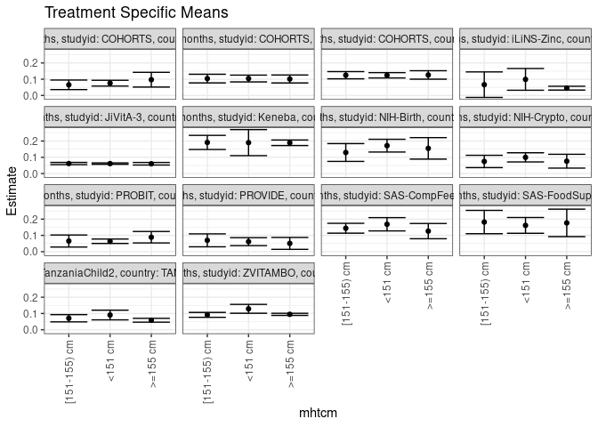

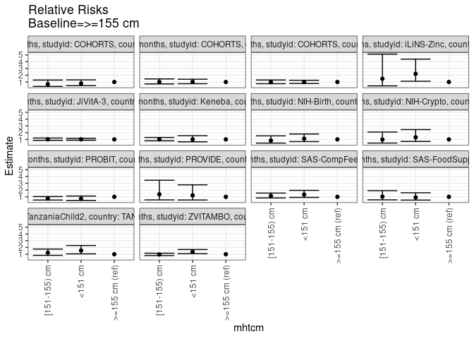

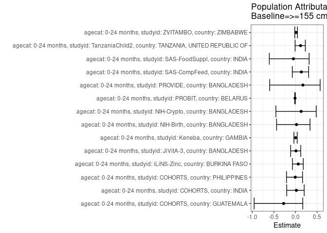

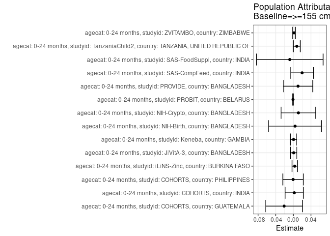

## Results Table

### Parameter: TSM

| agecat | studyid | country | intervention_level | baseline_level | estimate | ci_lower | ci_upper |
| --- | --- | --- | --- | --- | --- | --- | --- |
| 0-24 months | COHORTS | GUATEMALA | >=155 cm | NA | 0.0969991 | 0.0516404 | 0.1423578 |
| 0-24 months | COHORTS | GUATEMALA | <151 cm | NA | 0.0754735 | 0.0575466 | 0.0934004 |
| 0-24 months | COHORTS | GUATEMALA | [151-155) cm | NA | 0.0654594 | 0.0361256 | 0.0947932 |
| 0-24 months | COHORTS | INDIA | >=155 cm | NA | 0.1013497 | 0.0767379 | 0.1259615 |
| 0-24 months | COHORTS | INDIA | <151 cm | NA | 0.1042647 | 0.0833426 | 0.1251868 |
| 0-24 months | COHORTS | INDIA | [151-155) cm | NA | 0.1038094 | 0.0772040 | 0.1304148 |
| 0-24 months | COHORTS | PHILIPPINES | >=155 cm | NA | 0.1260952 | 0.1001022 | 0.1520882 |
| 0-24 months | COHORTS | PHILIPPINES | <151 cm | NA | 0.1241040 | 0.1077121 | 0.1404959 |
| 0-24 months | COHORTS | PHILIPPINES | [151-155) cm | NA | 0.1244862 | 0.1023162 | 0.1466562 |
| 0-24 months | iLiNS-Zinc | BURKINA FASO | >=155 cm | NA | 0.0448276 | 0.0330790 | 0.0565762 |
| 0-24 months | iLiNS-Zinc | BURKINA FASO | <151 cm | NA | 0.0989011 | 0.0320763 | 0.1657259 |
| 0-24 months | iLiNS-Zinc | BURKINA FASO | [151-155) cm | NA | 0.0663717 | -0.0121057 | 0.1448490 |
| 0-24 months | JiVitA-3 | BANGLADESH | >=155 cm | NA | 0.0603175 | 0.0525478 | 0.0680871 |
| 0-24 months | JiVitA-3 | BANGLADESH | <151 cm | NA | 0.0612066 | 0.0568940 | 0.0655191 |
| 0-24 months | JiVitA-3 | BANGLADESH | [151-155) cm | NA | 0.0615536 | 0.0547504 | 0.0683568 |
| 0-24 months | Keneba | GAMBIA | >=155 cm | NA | 0.1894258 | 0.1723180 | 0.2065336 |
| 0-24 months | Keneba | GAMBIA | <151 cm | NA | 0.1902339 | 0.1100538 | 0.2704141 |
| 0-24 months | Keneba | GAMBIA | [151-155) cm | NA | 0.1914944 | 0.1480619 | 0.2349268 |
| 0-24 months | NIH-Birth | BANGLADESH | >=155 cm | NA | 0.1548996 | 0.0887623 | 0.2210370 |
| 0-24 months | NIH-Birth | BANGLADESH | <151 cm | NA | 0.1716195 | 0.1324411 | 0.2107980 |
| 0-24 months | NIH-Birth | BANGLADESH | [151-155) cm | NA | 0.1294699 | 0.0746236 | 0.1843162 |
| 0-24 months | NIH-Crypto | BANGLADESH | >=155 cm | NA | 0.0759722 | 0.0335321 | 0.1184123 |
| 0-24 months | NIH-Crypto | BANGLADESH | <151 cm | NA | 0.0996500 | 0.0715332 | 0.1277668 |
| 0-24 months | NIH-Crypto | BANGLADESH | [151-155) cm | NA | 0.0745089 | 0.0366043 | 0.1124134 |
| 0-24 months | PROBIT | BELARUS | >=155 cm | NA | 0.0886383 | 0.0534346 | 0.1238420 |
| 0-24 months | PROBIT | BELARUS | <151 cm | NA | 0.0640000 | 0.0504110 | 0.0775890 |
| 0-24 months | PROBIT | BELARUS | [151-155) cm | NA | 0.0653266 | 0.0283038 | 0.1023494 |
| 0-24 months | PROVIDE | BANGLADESH | >=155 cm | NA | 0.0507246 | 0.0140860 | 0.0873632 |
| 0-24 months | PROVIDE | BANGLADESH | <151 cm | NA | 0.0616622 | 0.0372331 | 0.0860913 |
| 0-24 months | PROVIDE | BANGLADESH | [151-155) cm | NA | 0.0696203 | 0.0299064 | 0.1093341 |
| 0-24 months | SAS-CompFeed | INDIA | >=155 cm | NA | 0.1262242 | 0.0793840 | 0.1730644 |
| 0-24 months | SAS-CompFeed | INDIA | <151 cm | NA | 0.1684388 | 0.1275204 | 0.2093571 |
| 0-24 months | SAS-CompFeed | INDIA | [151-155) cm | NA | 0.1439283 | 0.1134905 | 0.1743661 |
| 0-24 months | SAS-FoodSuppl | INDIA | >=155 cm | NA | 0.1768332 | 0.0923595 | 0.2613068 |
| 0-24 months | SAS-FoodSuppl | INDIA | <151 cm | NA | 0.1614582 | 0.1128200 | 0.2100965 |
| 0-24 months | SAS-FoodSuppl | INDIA | [151-155) cm | NA | 0.1820724 | 0.1102907 | 0.2538541 |
| 0-24 months | TanzaniaChild2 | TANZANIA, UNITED REPUBLIC OF | >=155 cm | NA | 0.0583700 | 0.0464727 | 0.0702674 |
| 0-24 months | TanzaniaChild2 | TANZANIA, UNITED REPUBLIC OF | <151 cm | NA | 0.0905839 | 0.0607670 | 0.1204007 |
| 0-24 months | TanzaniaChild2 | TANZANIA, UNITED REPUBLIC OF | [151-155) cm | NA | 0.0707026 | 0.0484154 | 0.0929898 |
| 0-24 months | ZVITAMBO | ZIMBABWE | >=155 cm | NA | 0.0948257 | 0.0883286 | 0.1013228 |
| 0-24 months | ZVITAMBO | ZIMBABWE | <151 cm | NA | 0.1286732 | 0.1014332 | 0.1559131 |
| 0-24 months | ZVITAMBO | ZIMBABWE | [151-155) cm | NA | 0.0915463 | 0.0765337 | 0.1065588 |

### Parameter: E(Y)

| agecat | studyid | country | intervention_level | baseline_level | estimate | ci_lower | ci_upper |
| --- | --- | --- | --- | --- | --- | --- | --- |
| 0-24 months | COHORTS | GUATEMALA | NA | NA | 0.0760784 | 0.0615201 | 0.0906368 |
| 0-24 months | COHORTS | INDIA | NA | NA | 0.1034121 | 0.0897349 | 0.1170893 |
| 0-24 months | COHORTS | PHILIPPINES | NA | NA | 0.1254516 | 0.1136848 | 0.1372183 |
| 0-24 months | iLiNS-Zinc | BURKINA FASO | NA | NA | 0.0478707 | 0.0359037 | 0.0598376 |
| 0-24 months | JiVitA-3 | BANGLADESH | NA | NA | 0.0609979 | 0.0575023 | 0.0644934 |
| 0-24 months | Keneba | GAMBIA | NA | NA | 0.1898110 | 0.1742287 | 0.2053933 |
| 0-24 months | NIH-Birth | BANGLADESH | NA | NA | 0.1586538 | 0.1299648 | 0.1873429 |
| 0-24 months | NIH-Crypto | BANGLADESH | NA | NA | 0.0874172 | 0.0672569 | 0.1075775 |
| 0-24 months | PROBIT | BELARUS | NA | NA | 0.0877385 | 0.0529840 | 0.1224929 |
| 0-24 months | PROVIDE | BANGLADESH | NA | NA | 0.0612855 | 0.0430966 | 0.0794744 |
| 0-24 months | SAS-CompFeed | INDIA | NA | NA | 0.1460432 | 0.1145875 | 0.1774988 |
| 0-24 months | SAS-FoodSuppl | INDIA | NA | NA | 0.1687042 | 0.1323664 | 0.2050420 |
| 0-24 months | TanzaniaChild2 | TANZANIA, UNITED REPUBLIC OF | NA | NA | 0.0661297 | 0.0560993 | 0.0761601 |
| 0-24 months | ZVITAMBO | ZIMBABWE | NA | NA | 0.0962360 | 0.0904057 | 0.1020663 |

### Parameter: RR

| agecat | studyid | country | intervention_level | baseline_level | estimate | ci_lower | ci_upper |
| --- | --- | --- | --- | --- | --- | --- | --- |
| 0-24 months | COHORTS | GUATEMALA | >=155 cm | >=155 cm | 1.0000000 | 1.0000000 | 1.000000 |
| 0-24 months | COHORTS | GUATEMALA | <151 cm | >=155 cm | 0.7780842 | 0.4604616 | 1.314800 |
| 0-24 months | COHORTS | GUATEMALA | [151-155) cm | >=155 cm | 0.6748453 | 0.3530984 | 1.289771 |
| 0-24 months | COHORTS | INDIA | >=155 cm | >=155 cm | 1.0000000 | 1.0000000 | 1.000000 |
| 0-24 months | COHORTS | INDIA | <151 cm | >=155 cm | 1.0287613 | 0.7507067 | 1.409805 |
| 0-24 months | COHORTS | INDIA | [151-155) cm | >=155 cm | 1.0242695 | 0.7195551 | 1.458023 |
| 0-24 months | COHORTS | PHILIPPINES | >=155 cm | >=155 cm | 1.0000000 | 1.0000000 | 1.000000 |
| 0-24 months | COHORTS | PHILIPPINES | <151 cm | >=155 cm | 0.9842091 | 0.7704098 | 1.257340 |
| 0-24 months | COHORTS | PHILIPPINES | [151-155) cm | >=155 cm | 0.9872399 | 0.7518190 | 1.296380 |
| 0-24 months | iLiNS-Zinc | BURKINA FASO | >=155 cm | >=155 cm | 1.0000000 | 1.0000000 | 1.000000 |
| 0-24 months | iLiNS-Zinc | BURKINA FASO | <151 cm | >=155 cm | 2.2062553 | 1.1131512 | 4.372777 |
| 0-24 months | iLiNS-Zinc | BURKINA FASO | [151-155) cm | >=155 cm | 1.4805990 | 0.4280422 | 5.121396 |
| 0-24 months | JiVitA-3 | BANGLADESH | >=155 cm | >=155 cm | 1.0000000 | 1.0000000 | 1.000000 |
| 0-24 months | JiVitA-3 | BANGLADESH | <151 cm | >=155 cm | 1.0147402 | 0.8823058 | 1.167053 |
| 0-24 months | JiVitA-3 | BANGLADESH | [151-155) cm | >=155 cm | 1.0204937 | 0.8644818 | 1.204661 |
| 0-24 months | Keneba | GAMBIA | >=155 cm | >=155 cm | 1.0000000 | 1.0000000 | 1.000000 |
| 0-24 months | Keneba | GAMBIA | <151 cm | >=155 cm | 1.0042660 | 0.6525370 | 1.545583 |
| 0-24 months | Keneba | GAMBIA | [151-155) cm | >=155 cm | 1.0109200 | 0.7919259 | 1.290473 |
| 0-24 months | NIH-Birth | BANGLADESH | >=155 cm | >=155 cm | 1.0000000 | 1.0000000 | 1.000000 |
| 0-24 months | NIH-Birth | BANGLADESH | <151 cm | >=155 cm | 1.1079403 | 0.6822133 | 1.799337 |
| 0-24 months | NIH-Birth | BANGLADESH | [151-155) cm | >=155 cm | 0.8358309 | 0.4577683 | 1.526128 |
| 0-24 months | NIH-Crypto | BANGLADESH | >=155 cm | >=155 cm | 1.0000000 | 1.0000000 | 1.000000 |
| 0-24 months | NIH-Crypto | BANGLADESH | <151 cm | >=155 cm | 1.3116640 | 0.7010877 | 2.453990 |
| 0-24 months | NIH-Crypto | BANGLADESH | [151-155) cm | >=155 cm | 0.9807388 | 0.4607783 | 2.087443 |
| 0-24 months | PROBIT | BELARUS | >=155 cm | >=155 cm | 1.0000000 | 1.0000000 | 1.000000 |
| 0-24 months | PROBIT | BELARUS | <151 cm | >=155 cm | 0.7220359 | 0.4679692 | 1.114039 |
| 0-24 months | PROBIT | BELARUS | [151-155) cm | >=155 cm | 0.7370027 | 0.5240840 | 1.036423 |
| 0-24 months | PROVIDE | BANGLADESH | >=155 cm | >=155 cm | 1.0000000 | 1.0000000 | 1.000000 |
| 0-24 months | PROVIDE | BANGLADESH | <151 cm | >=155 cm | 1.2156262 | 0.5333591 | 2.770642 |
| 0-24 months | PROVIDE | BANGLADESH | [151-155) cm | >=155 cm | 1.3725136 | 0.5467589 | 3.445383 |
| 0-24 months | SAS-CompFeed | INDIA | >=155 cm | >=155 cm | 1.0000000 | 1.0000000 | 1.000000 |
| 0-24 months | SAS-CompFeed | INDIA | <151 cm | >=155 cm | 1.3344409 | 0.9129249 | 1.950579 |
| 0-24 months | SAS-CompFeed | INDIA | [151-155) cm | >=155 cm | 1.1402589 | 0.8363462 | 1.554608 |
| 0-24 months | SAS-FoodSuppl | INDIA | >=155 cm | >=155 cm | 1.0000000 | 1.0000000 | 1.000000 |
| 0-24 months | SAS-FoodSuppl | INDIA | <151 cm | >=155 cm | 0.9130541 | 0.5197232 | 1.604061 |
| 0-24 months | SAS-FoodSuppl | INDIA | [151-155) cm | >=155 cm | 1.0296280 | 0.5546522 | 1.911349 |
| 0-24 months | TanzaniaChild2 | TANZANIA, UNITED REPUBLIC OF | >=155 cm | >=155 cm | 1.0000000 | 1.0000000 | 1.000000 |
| 0-24 months | TanzaniaChild2 | TANZANIA, UNITED REPUBLIC OF | <151 cm | >=155 cm | 1.5518898 | 1.0536369 | 2.285761 |
| 0-24 months | TanzaniaChild2 | TANZANIA, UNITED REPUBLIC OF | [151-155) cm | >=155 cm | 1.2112823 | 0.8321852 | 1.763075 |
| 0-24 months | ZVITAMBO | ZIMBABWE | >=155 cm | >=155 cm | 1.0000000 | 1.0000000 | 1.000000 |
| 0-24 months | ZVITAMBO | ZIMBABWE | <151 cm | >=155 cm | 1.3569434 | 1.0862411 | 1.695107 |
| 0-24 months | ZVITAMBO | ZIMBABWE | [151-155) cm | >=155 cm | 0.9654157 | 0.8082230 | 1.153181 |

### Parameter: PAR

| agecat | studyid | country | intervention_level | baseline_level | estimate | ci_lower | ci_upper |
| --- | --- | --- | --- | --- | --- | --- | --- |
| 0-24 months | COHORTS | GUATEMALA | >=155 cm | NA | -0.0209207 | -0.0626259 | 0.0207845 |
| 0-24 months | COHORTS | INDIA | >=155 cm | NA | 0.0020624 | -0.0186992 | 0.0228239 |
| 0-24 months | COHORTS | PHILIPPINES | >=155 cm | NA | -0.0006436 | -0.0238132 | 0.0225259 |
| 0-24 months | iLiNS-Zinc | BURKINA FASO | >=155 cm | NA | 0.0030431 | -0.0031079 | 0.0091941 |
| 0-24 months | JiVitA-3 | BANGLADESH | >=155 cm | NA | 0.0006804 | -0.0064091 | 0.0077699 |
| 0-24 months | Keneba | GAMBIA | >=155 cm | NA | 0.0003852 | -0.0067806 | 0.0075510 |
| 0-24 months | NIH-Birth | BANGLADESH | >=155 cm | NA | 0.0037542 | -0.0561417 | 0.0636501 |
| 0-24 months | NIH-Crypto | BANGLADESH | >=155 cm | NA | 0.0114450 | -0.0277918 | 0.0506818 |
| 0-24 months | PROBIT | BELARUS | >=155 cm | NA | -0.0008998 | -0.0016588 | -0.0001408 |
| 0-24 months | PROVIDE | BANGLADESH | >=155 cm | NA | 0.0105609 | -0.0228968 | 0.0440185 |
| 0-24 months | SAS-CompFeed | INDIA | >=155 cm | NA | 0.0198189 | -0.0059434 | 0.0455813 |
| 0-24 months | SAS-FoodSuppl | INDIA | >=155 cm | NA | -0.0081290 | -0.0836366 | 0.0673786 |
| 0-24 months | TanzaniaChild2 | TANZANIA, UNITED REPUBLIC OF | >=155 cm | NA | 0.0077597 | -0.0001289 | 0.0156483 |
| 0-24 months | ZVITAMBO | ZIMBABWE | >=155 cm | NA | 0.0014103 | -0.0016064 | 0.0044269 |

### Parameter: PAF

| agecat | studyid | country | intervention_level | baseline_level | estimate | ci_lower | ci_upper |
| --- | --- | --- | --- | --- | --- | --- | --- |
| 0-24 months | COHORTS | GUATEMALA | >=155 cm | NA | -0.2749884 | -0.9567043 | 0.1692177 |
| 0-24 months | COHORTS | INDIA | >=155 cm | NA | 0.0199431 | -0.2028155 | 0.2014474 |
| 0-24 months | COHORTS | PHILIPPINES | >=155 cm | NA | -0.0051306 | -0.2078771 | 0.1635842 |
| 0-24 months | iLiNS-Zinc | BURKINA FASO | >=155 cm | NA | 0.0635692 | -0.0699048 | 0.1803918 |
| 0-24 months | JiVitA-3 | BANGLADESH | >=155 cm | NA | 0.0111545 | -0.1121474 | 0.1207861 |
| 0-24 months | Keneba | GAMBIA | >=155 cm | NA | 0.0020293 | -0.0364455 | 0.0390759 |
| 0-24 months | NIH-Birth | BANGLADESH | >=155 cm | NA | 0.0236630 | -0.4372141 | 0.3367488 |
| 0-24 months | NIH-Crypto | BANGLADESH | >=155 cm | NA | 0.1309240 | -0.4537148 | 0.4804393 |
| 0-24 months | PROBIT | BELARUS | >=155 cm | NA | -0.0102554 | -0.0173672 | -0.0031934 |
| 0-24 months | PROVIDE | BANGLADESH | >=155 cm | NA | 0.1723224 | -0.5965976 | 0.5709312 |
| 0-24 months | SAS-CompFeed | INDIA | >=155 cm | NA | 0.1357061 | -0.0745365 | 0.3048128 |
| 0-24 months | SAS-FoodSuppl | INDIA | >=155 cm | NA | -0.0481850 | -0.6063562 | 0.3160348 |
| 0-24 months | TanzaniaChild2 | TANZANIA, UNITED REPUBLIC OF | >=155 cm | NA | 0.1173403 | -0.0091603 | 0.2279838 |
| 0-24 months | ZVITAMBO | ZIMBABWE | >=155 cm | NA | 0.0146544 | -0.0171858 | 0.0454978 |